# Chapter 2 excercises

Hugo Åkerstrand

2023-09-05

### 2.2.5

```r
penguins %>% nrow()
```

```
## [1] 344
```

```r
?penguins
```

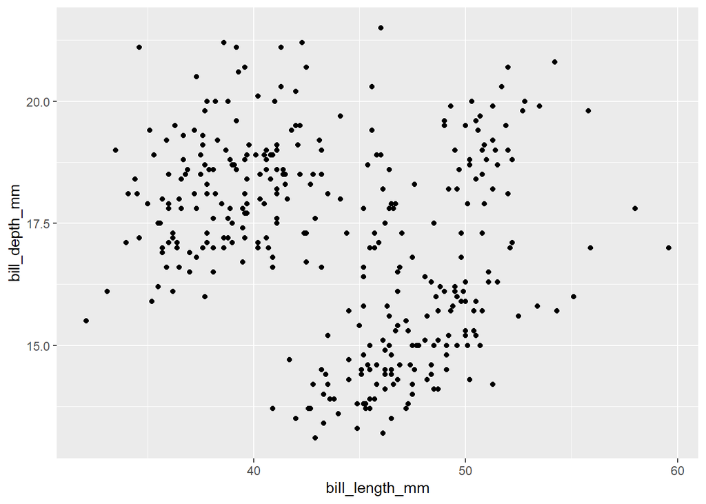

```r
ggplot(data = penguins,
       mapping = aes(
         x = bill_length_mm,
         y = bill_depth_mm )
       )+
  geom_point()
```

Consider using a box plot instead.

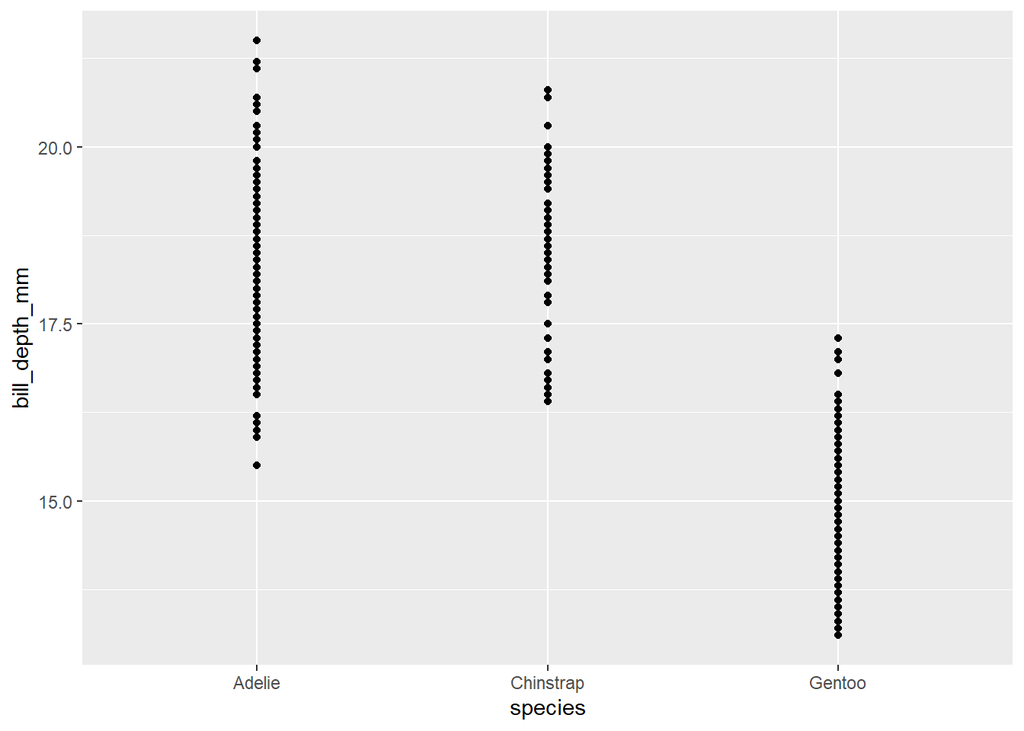

```r
ggplot( data = penguins,
        mapping = aes(
          x = species,
          y = bill_depth_mm)
        )+
  geom_point()
```

You need to define aesthetics.

```r
ggplot(data = penguins) +
  geom_point()
```

```
## Error in `check_required_aesthetics()`:
## ! geom_point requires the following missing aesthetics: x and y
```

`na.rm` removes the observations (rows) where an NA is noted (i.e. missing data).

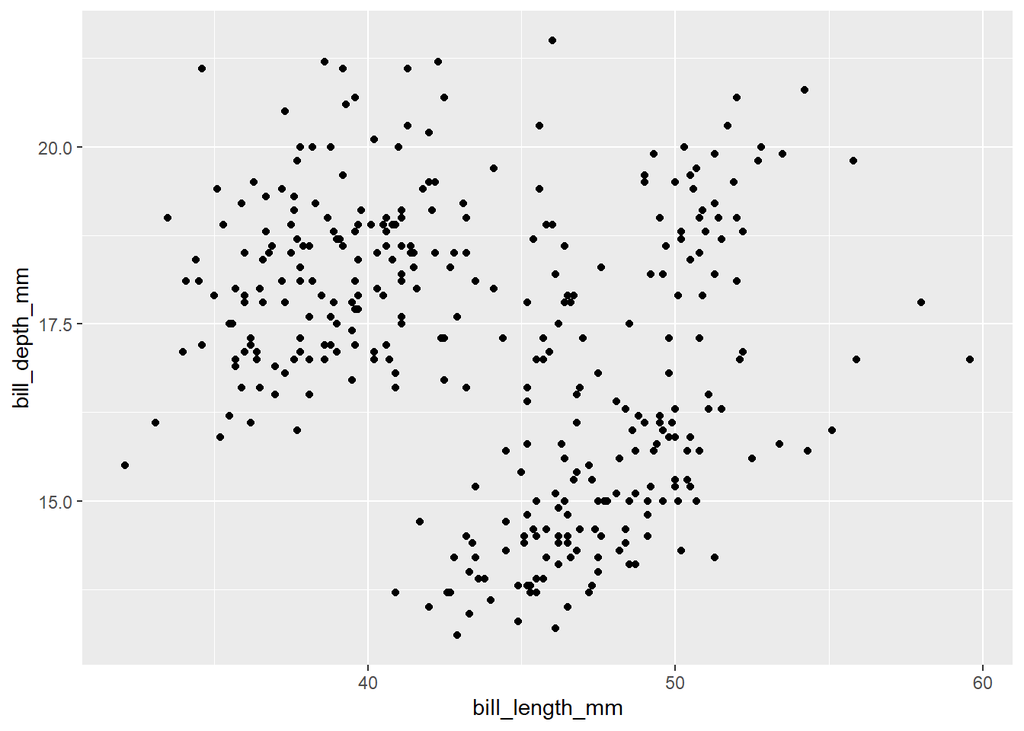

```r
ggplot(data = penguins,
       mapping = aes(
         x = bill_length_mm,
         y = bill_depth_mm)
       )+
  geom_point(na.rm = T)
```

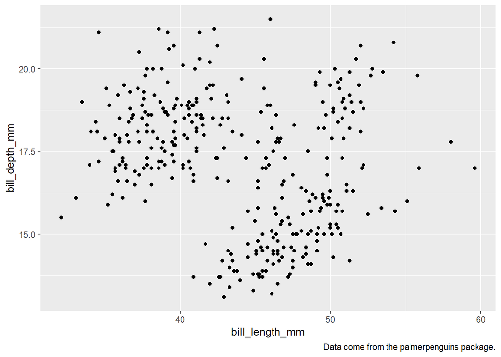

```r
ggplot( data = penguins,
        mapping = aes(
          x = bill_length_mm,
          y = bill_depth_mm)
          )+
  geom_point(na.rm = T)+
  labs(caption = "Data come from the palmerpenguins package.")
```

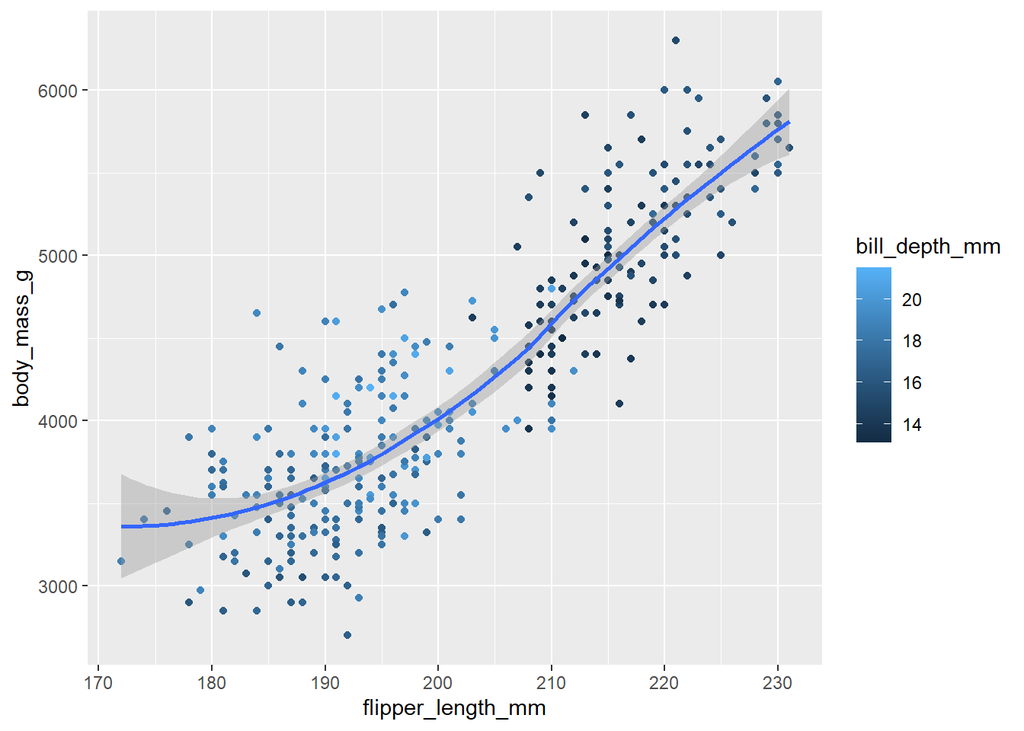

```r
ggplot( data = penguins,
        mapping = aes(
          x = flipper_length_mm,
          y = body_mass_g,
          color = bill_depth_mm)
        )+
  geom_point()+
  geom_smooth()
```

The plot will look like 8, but with curves and geom_point color by island, and no confidence interval.

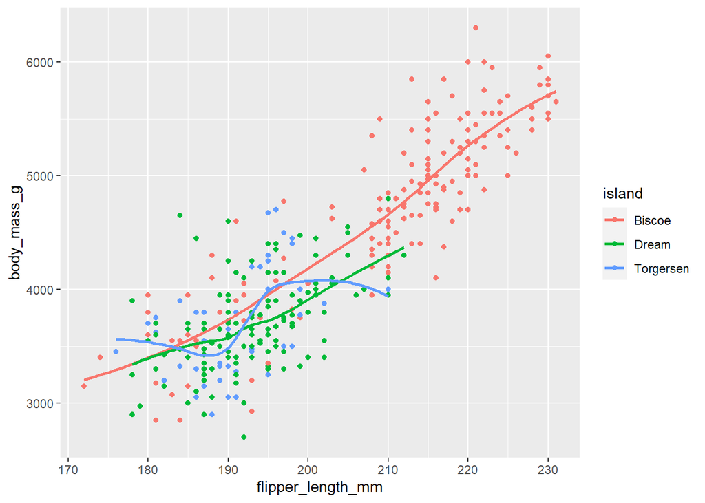

```r
ggplot( data = penguins,
        mapping = aes(
          x = flipper_length_mm,
          y = body_mass_g,
          color = island)
        )+
  geom_point()+
  geom_smooth(se = FALSE)
```

They two plots will look the same as the same aesthetics are called, in different ways.

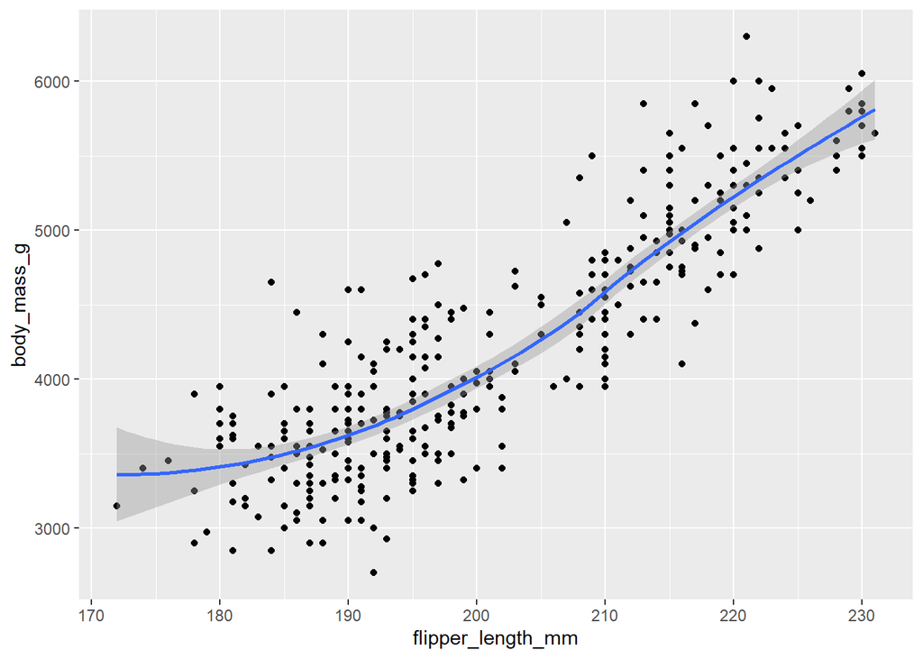

```r
ggplot(data = penguins,
        mapping = aes(
          x = flipper_length_mm,
          y = body_mass_g)
        )+
  geom_point()+
  geom_smooth()
```

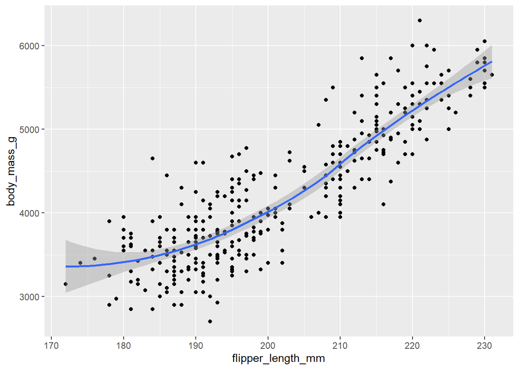

```r
ggplot()+
  geom_point(data = penguins,
             mapping = aes(
               x = flipper_length_mm,
               y = body_mass_g)
             )+
  geom_smooth(data = penguins,
              mapping = aes(
                x = flipper_length_mm,
                y = body_mass_g)
              )
```

### 2.4.3

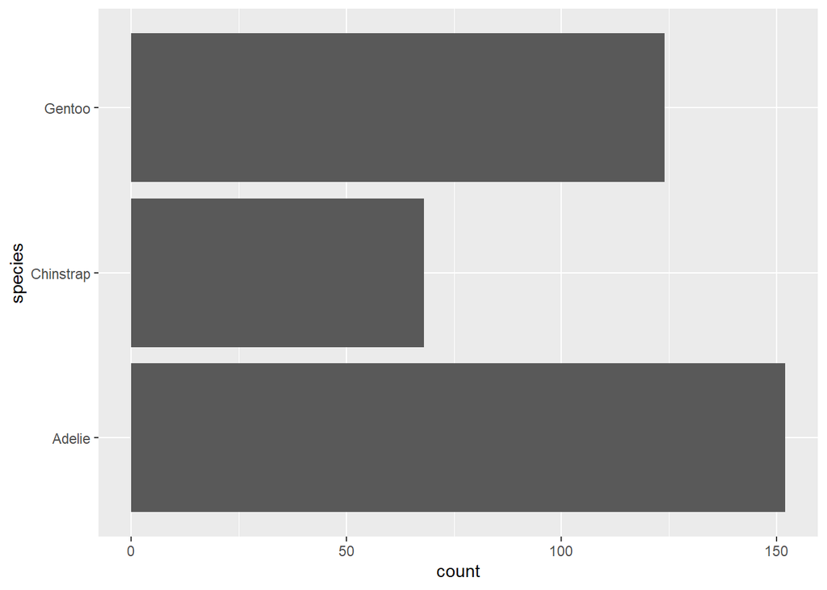

```r
ggplot(penguins,
       aes(y = species)
       )+
  geom_bar()
```

2. Fill is more useful for bars.

ggplot(penguins, aes(x = species)) + geom_bar(color = “red”)

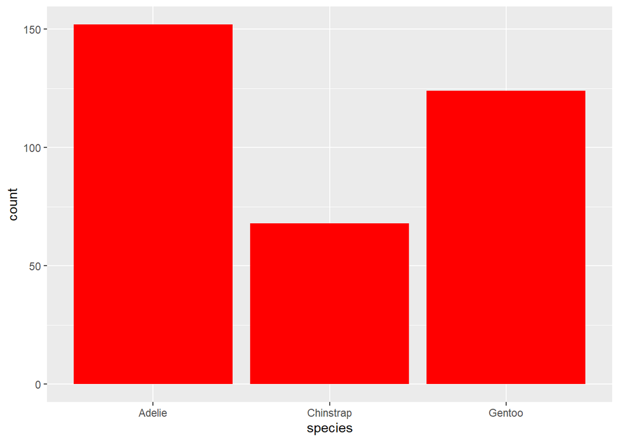

```r
ggplot(penguins, aes(x = species)) + geom_bar(fill = "red")
```

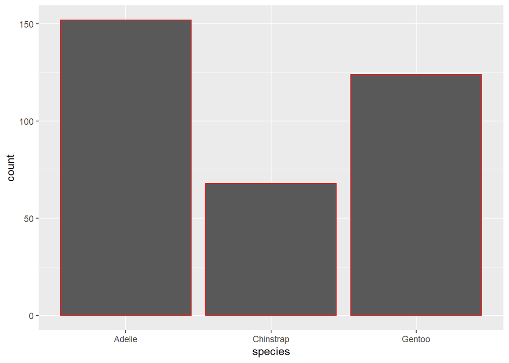

```r
ggplot(penguins, aes(x = species)) + geom_bar(color = "red")
```

`bins` overrides `binwidth` by defining a set number of bins that the data is divided into.

```r
diamonds %>% summarise(min = min(carat), max = max(carat))
```

```
## # A tibble: 1 x 2
##     min   max
##   <dbl> <dbl>
## 1   0.2  5.01
```

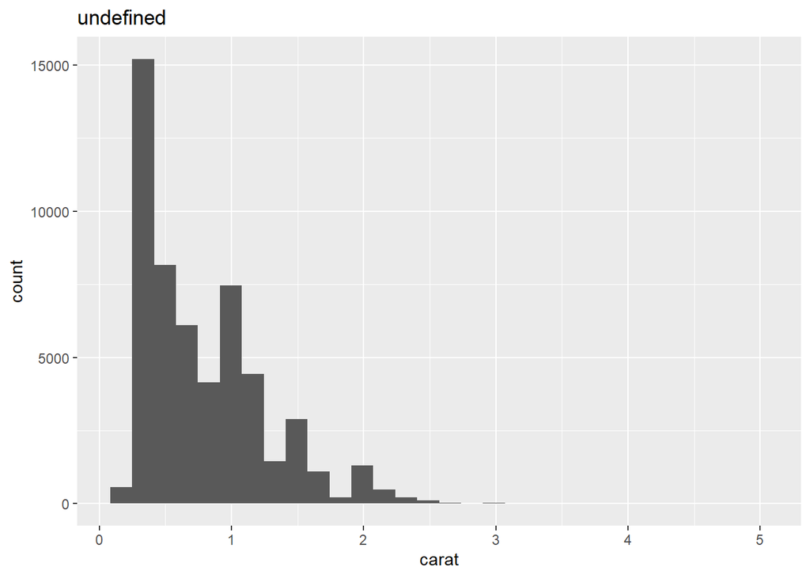

```r
diamonds %>%
  ggplot(aes(x = carat))+
  geom_histogram()+
  labs(title = "undefined")
```

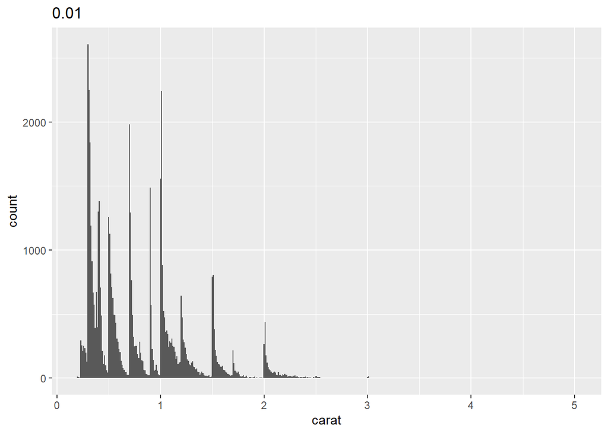

```r
diamonds %>%
  ggplot(aes(x = carat))+
  geom_histogram(binwidth = 0.01)+
  labs(title = "0.01")
```

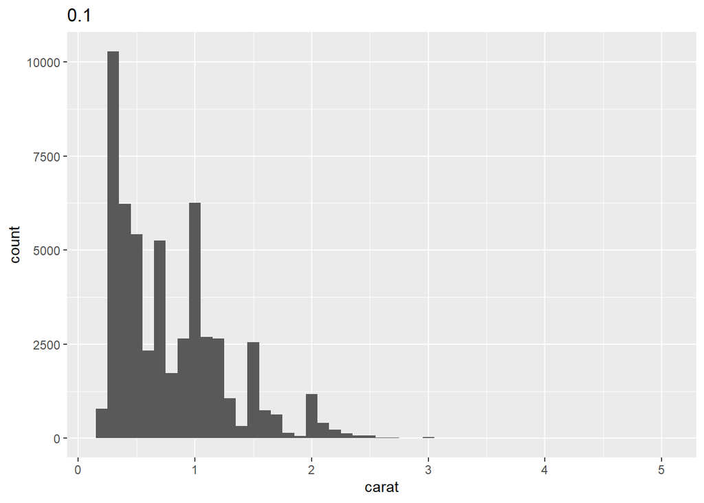

```r
diamonds %>%
  ggplot(aes(x = carat))+
  geom_histogram(binwidth = 0.1)+
  labs(title = "0.1")
```

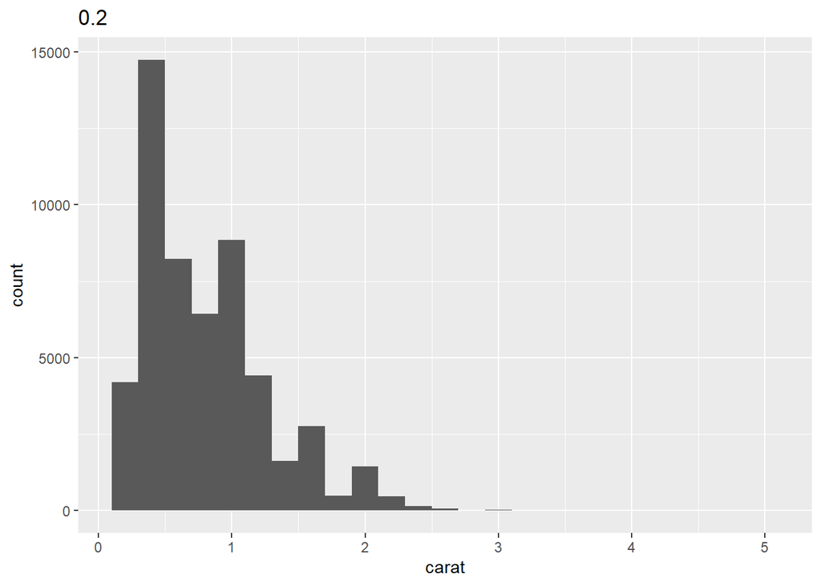

```r
diamonds %>%
  ggplot(aes(x = carat))+
  geom_histogram(binwidth = 0.2)+
  labs(title = "0.2")
```

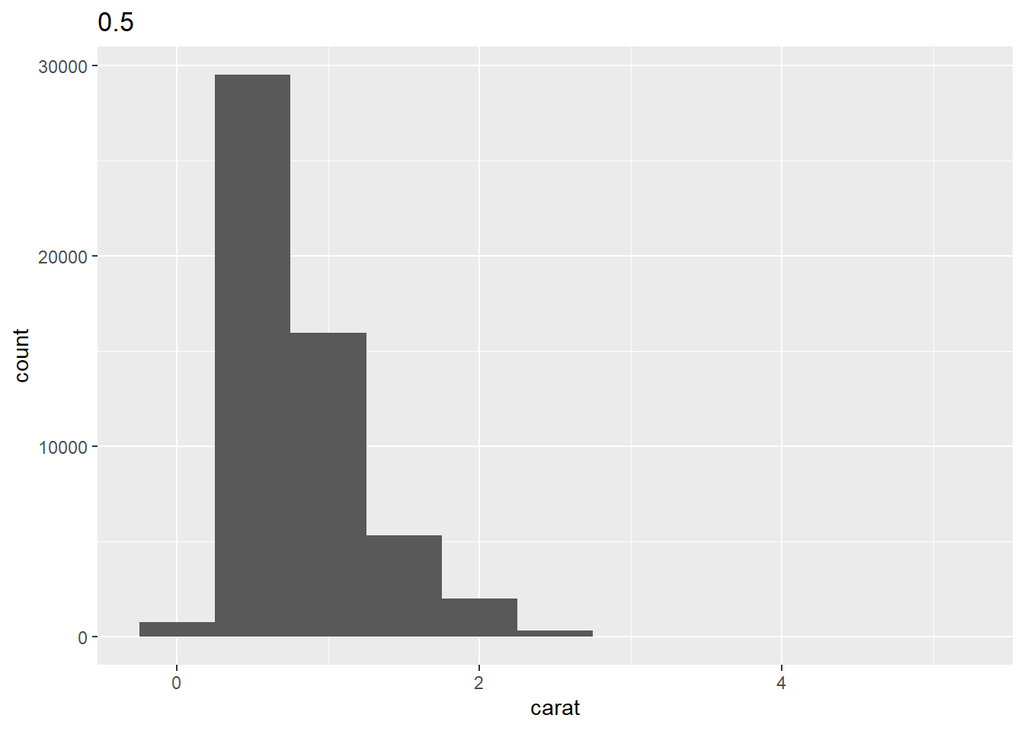

```r
diamonds %>%
  ggplot(aes(x = carat))+
  geom_histogram(binwidth = 0.5)+
  labs(title = "0.5")
```

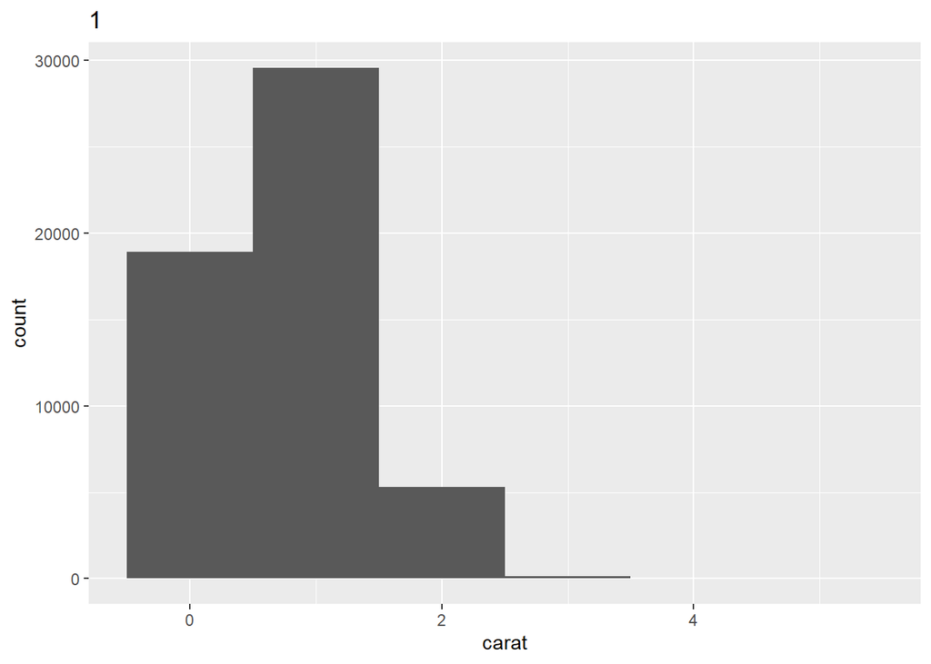

```r
diamonds %>%
  ggplot(aes(x = carat))+
  geom_histogram(binwidth = 1)+
  labs(title = "1")
```

### 2.5.5

Easiest is to count number of character (categorical) versus numeric (dbl and int)

```r
mpg %>% glimpse()
```

```
## Rows: 234
## Columns: 11
## $ manufacturer <chr> "audi", "audi", "audi", "audi", "audi", "audi", "audi", "audi", "audi", "audi", "audi", "audi", "audi", "audi", "audi", "audi", "audi", "audi", "chevrolet", "chevrolet", "chevro~
## $ model        <chr> "a4", "a4", "a4", "a4", "a4", "a4", "a4", "a4 quattro", "a4 quattro", "a4 quattro", "a4 quattro", "a4 quattro", "a4 quattro", "a4 quattro", "a4 quattro", "a6 quattro", "a6 quatt~
## $ displ        <dbl> 1.8, 1.8, 2.0, 2.0, 2.8, 2.8, 3.1, 1.8, 1.8, 2.0, 2.0, 2.8, 2.8, 3.1, 3.1, 2.8, 3.1, 4.2, 5.3, 5.3, 5.3, 5.7, 6.0, 5.7, 5.7, 6.2, 6.2, 7.0, 5.3, 5.3, 5.7, 6.5, 2.4, 2.4, 3.1, 3.~
## $ year         <int> 1999, 1999, 2008, 2008, 1999, 1999, 2008, 1999, 1999, 2008, 2008, 1999, 1999, 2008, 2008, 1999, 2008, 2008, 2008, 2008, 2008, 1999, 2008, 1999, 1999, 2008, 2008, 2008, 2008, 200~
## $ cyl          <int> 4, 4, 4, 4, 6, 6, 6, 4, 4, 4, 4, 6, 6, 6, 6, 6, 6, 8, 8, 8, 8, 8, 8, 8, 8, 8, 8, 8, 8, 8, 8, 8, 4, 4, 6, 6, 6, 4, 6, 6, 6, 6, 6, 6, 6, 6, 6, 6, 6, 6, 6, 6, 8, 8, 8, 8, 8, 6, 8, ~
## $ trans        <chr> "auto(l5)", "manual(m5)", "manual(m6)", "auto(av)", "auto(l5)", "manual(m5)", "auto(av)", "manual(m5)", "auto(l5)", "manual(m6)", "auto(s6)", "auto(l5)", "manual(m5)", "auto(s6)~
## $ drv          <chr> "f", "f", "f", "f", "f", "f", "f", "4", "4", "4", "4", "4", "4", "4", "4", "4", "4", "4", "r", "r", "r", "r", "r", "r", "r", "r", "r", "r", "4", "4", "4", "4", "f", "f", "f", "f~
## $ cty          <int> 18, 21, 20, 21, 16, 18, 18, 18, 16, 20, 19, 15, 17, 17, 15, 15, 17, 16, 14, 11, 14, 13, 12, 16, 15, 16, 15, 15, 14, 11, 11, 14, 19, 22, 18, 18, 17, 18, 17, 16, 16, 17, 17, 11, 1~
## $ hwy          <int> 29, 29, 31, 30, 26, 26, 27, 26, 25, 28, 27, 25, 25, 25, 25, 24, 25, 23, 20, 15, 20, 17, 17, 26, 23, 26, 25, 24, 19, 14, 15, 17, 27, 30, 26, 29, 26, 24, 24, 22, 22, 24, 24, 17, 2~
## $ fl           <chr> "p", "p", "p", "p", "p", "p", "p", "p", "p", "p", "p", "p", "p", "p", "p", "p", "p", "p", "r", "e", "r", "r", "r", "p", "p", "p", "p", "p", "r", "e", "r", "d", "r", "r", "r", "r~
## $ class        <chr> "compact", "compact", "compact", "compact", "compact", "compact", "compact", "compact", "compact", "compact", "compact", "compact", "compact", "compact", "compact", "midsize", "~
```

```r
numeric <- mpg %>% select(where(is.numeric)) %>% length()
cat <- mpg %>% select(!where(is.numeric)) %>% length()
numeric
```

```
## [1] 5
```

```r
cat
```

```
## [1] 6
```

Shape cannot be mapped to a continuous variable.

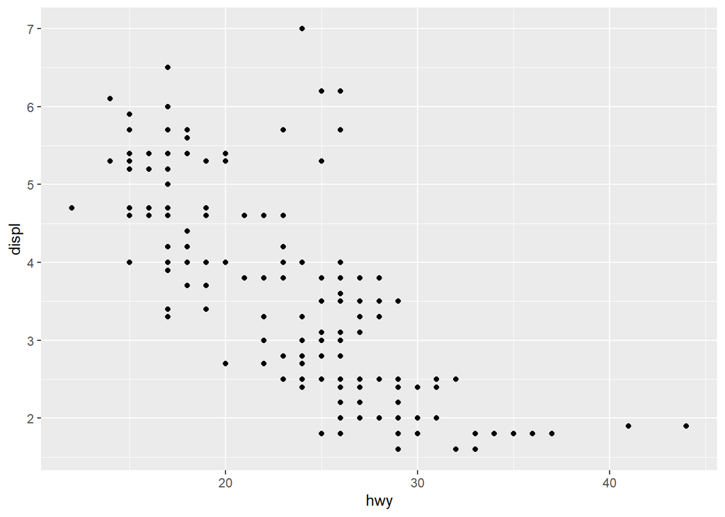

```r
mpg %>%
  ggplot(aes(x = hwy, y = displ))+ geom_point()
```

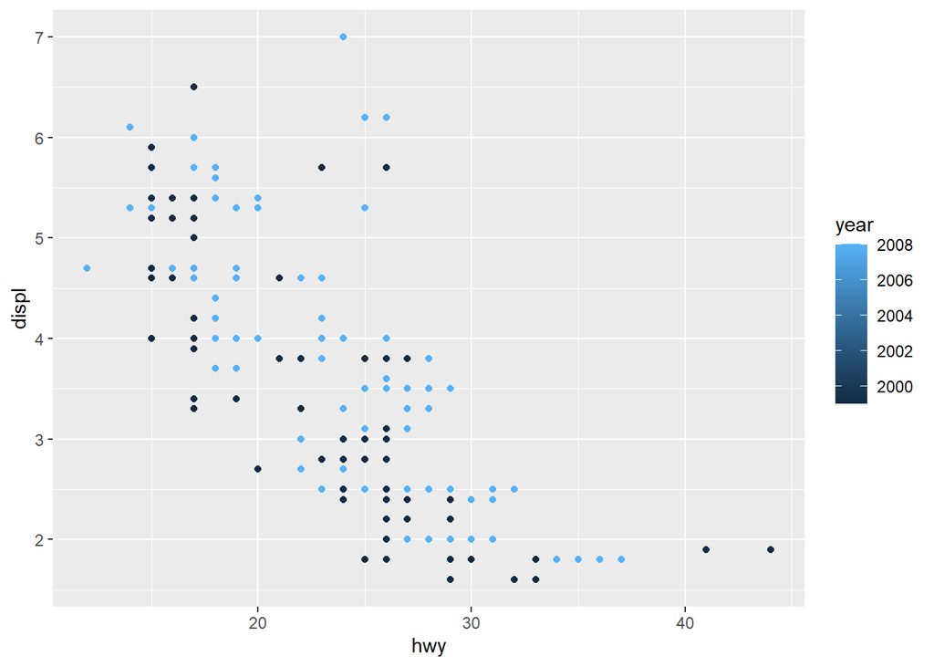

```r
mpg %>%
  ggplot(aes(x = hwy, y = displ, color = year))+ geom_point()
```

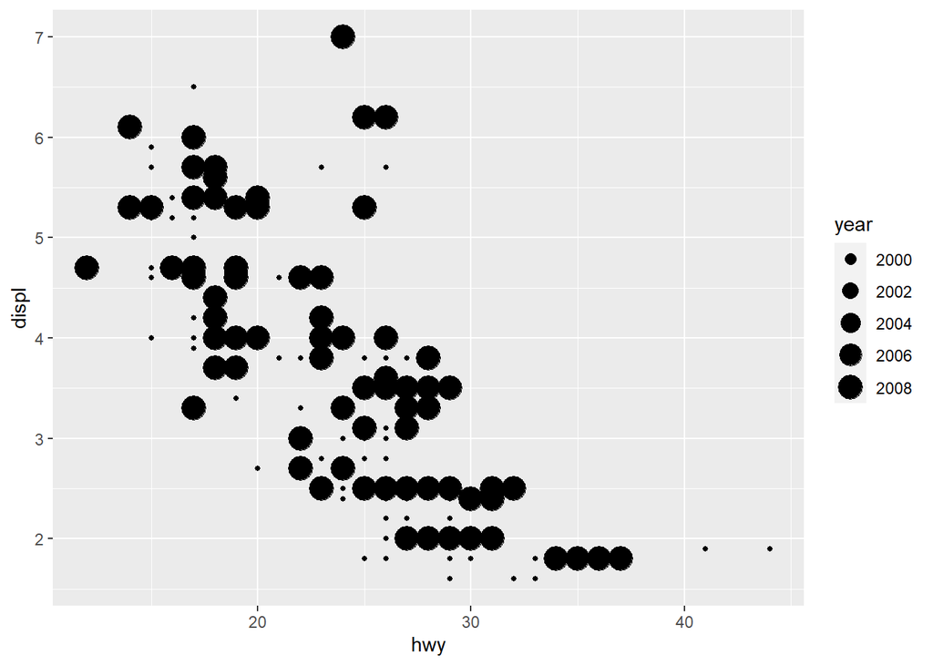

```r
mpg %>%
  ggplot(aes(x = hwy, y = displ, size = year))+ geom_point()
```

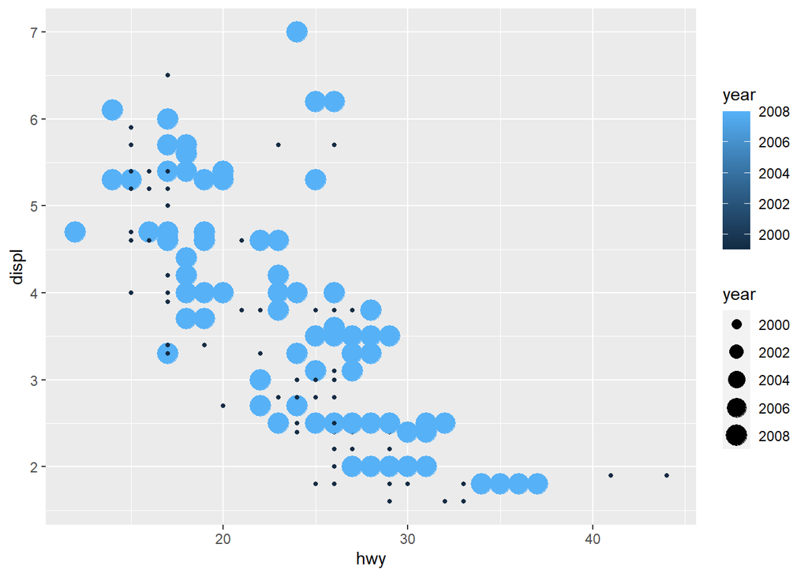

```r
mpg %>%
  ggplot(aes(x = hwy, y = displ, color = year, size = year))+ geom_point()
```

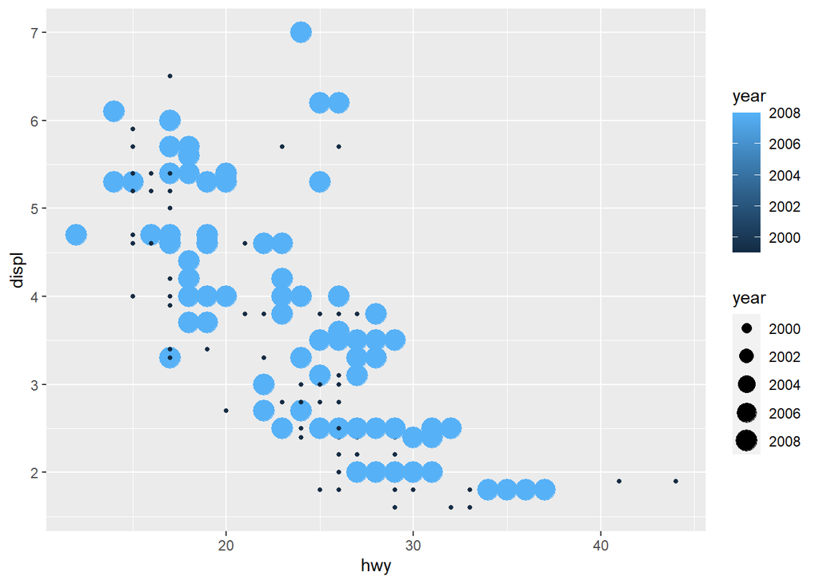

```r
mpg %>%
  ggplot(aes(x = hwy,
             y = displ,
             color = year,
             size = year,
             linewidth = cty)
         )+
  geom_point()
```

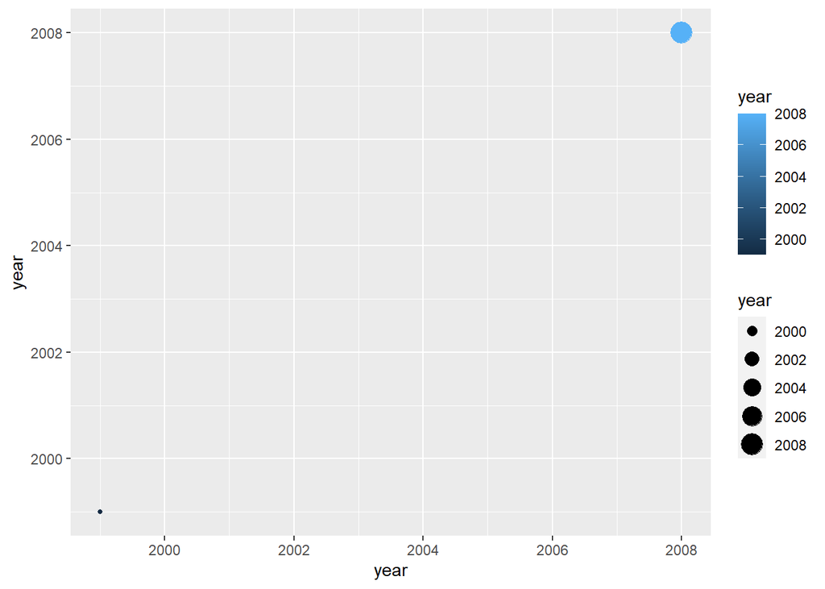

```r
mpg %>%
  ggplot(aes(
    x = year,
    y = year,
    color = year,
    size = year,
    linewidth = year)
    )+
  geom_point()
```

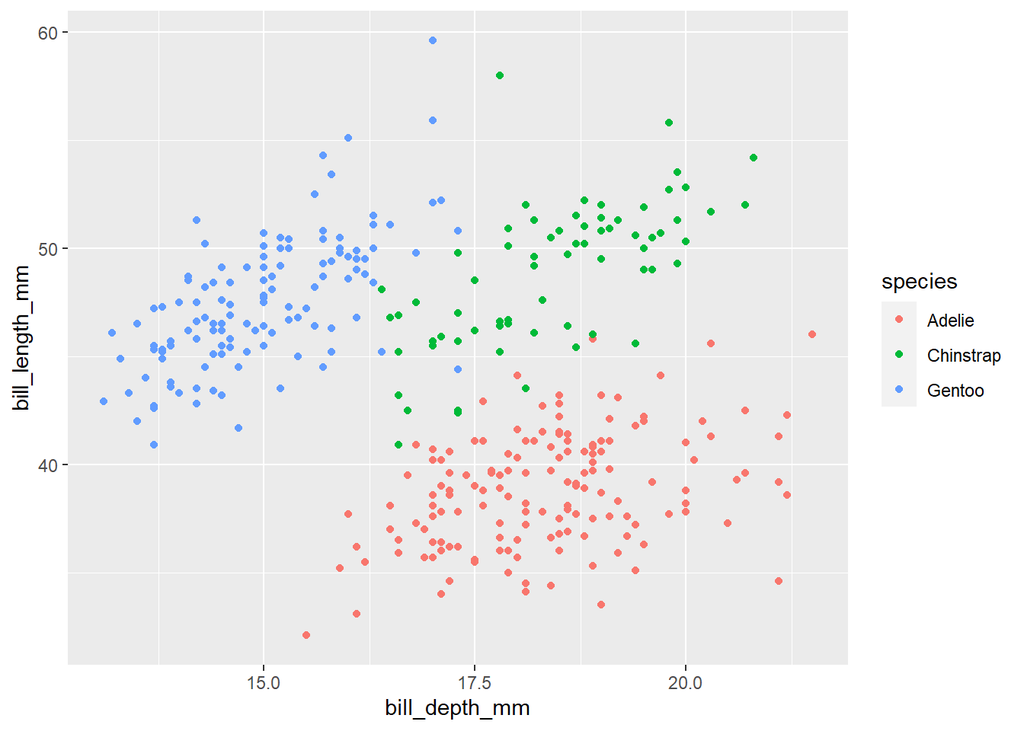

```r
penguins %>%
  ggplot(aes(
    x = bill_depth_mm,
    y = bill_length_mm,
    color = species)
    )+
  geom_point()
```

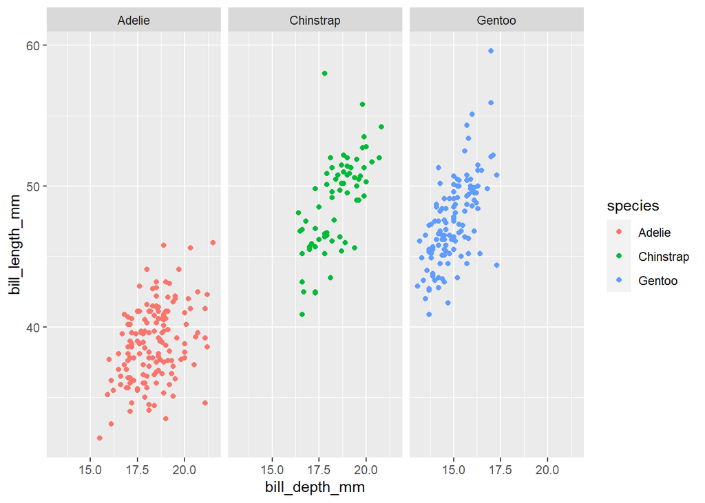

```r
penguins %>%
  ggplot(aes(
    x = bill_depth_mm,
    y = bill_length_mm,
    color = species)
    )+
  geom_point()+
  facet_wrap(~species)
```

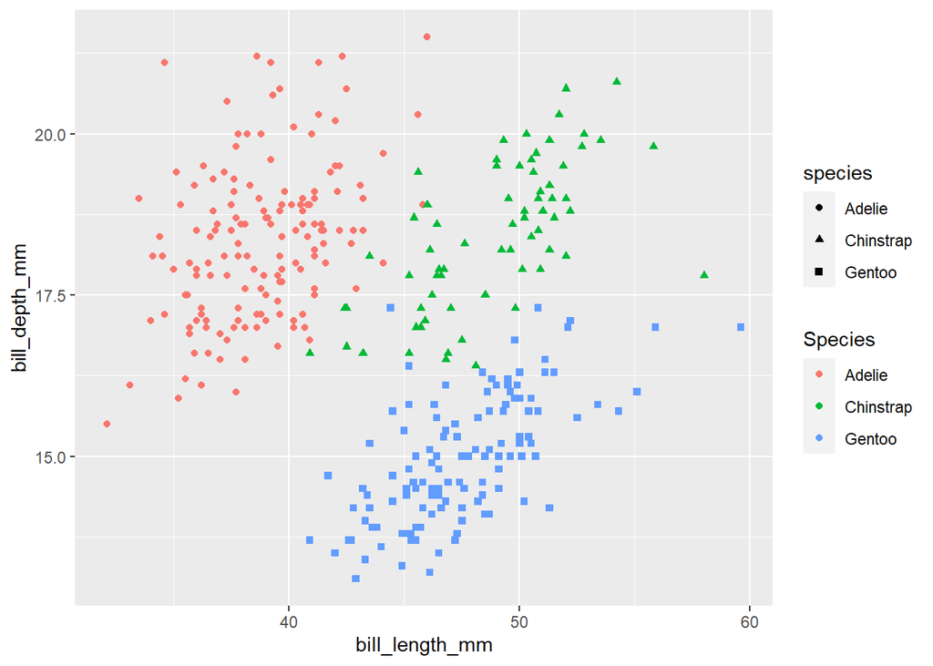

```r
ggplot(data = penguins,
       mapping = aes(
         x = bill_length_mm,
         y = bill_depth_mm,
         color = species,
         shape = species)
       )+
  geom_point()+
labs(color = "Species")
```

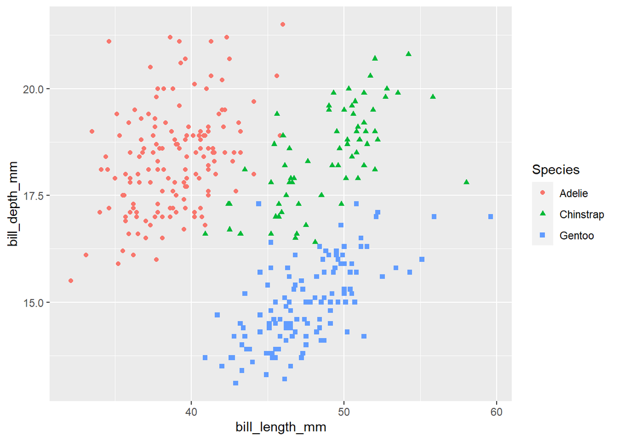

```r
ggplot( data = penguins,
        mapping = aes(x = bill_length_mm,
                      y = bill_depth_mm,
                      color = species,
                      shape = species)
        )+
  geom_point()+
labs(color = "Species", shape = "Species")
```

7. They show island or species on x, and fill by the other variable - thereby comparing island or species, depending on what is on X.

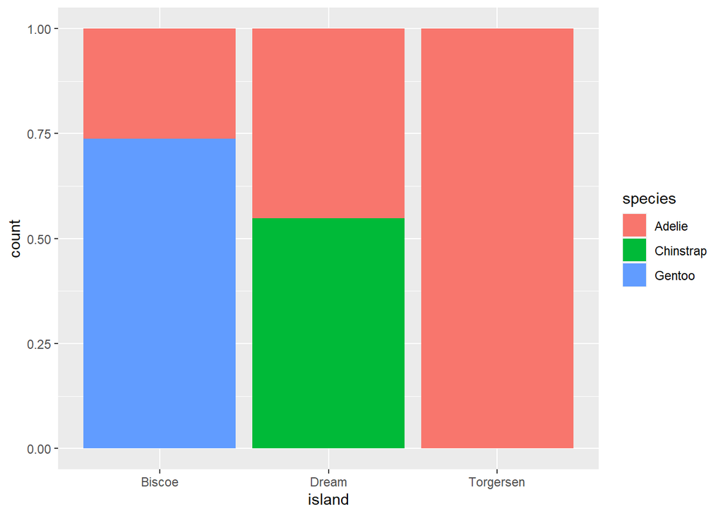

```r
ggplot(penguins,
       aes(
         x = island,
         fill = species)
       )+
  geom_bar(position = "fill")
```

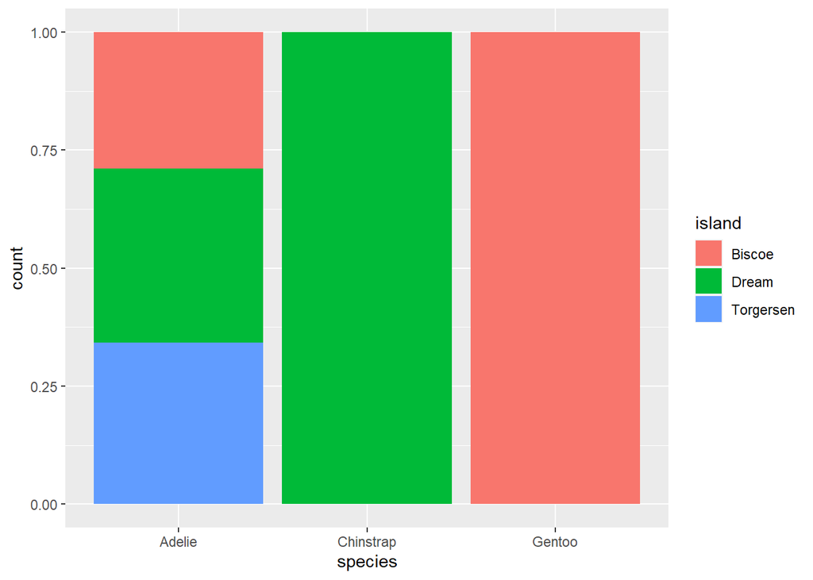

```r
ggplot(penguins,
       aes(
         x = species,
         fill = island)
       )+
  geom_bar(position = "fill")
```

### 2.6.1

In `ggsave`, the `plot` option defaults to `last_plot()`, unless otherwise specified.

You change file ending to .pdf, you can check available output formats using `?ggsave()`.